# Table of Contents

```python
import pandas as pd
import numpy as np

import os
import unicodedata
import re
import json

import nltk
from nltk.tokenize.toktok import ToktokTokenizer
from nltk.corpus import stopwords
from nltk.util import ngrams

import matplotlib.pyplot as plt
%matplotlib inline
plt.rcParams['figure.figsize'] = (14, 6)
from pylab import *
import seaborn as sns
from wordcloud import WordCloud

from acquire_walkthrough import get_news_articles
from prepare_walkthrough import prep_article_data, remove_stopwords
```

## Exploring Text Data

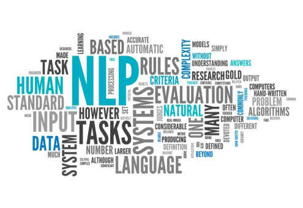

### **What is Text Data?**

#### **Important Terminology**

**The Corpus -** refers to the entire body of text. A collection of articles is a corpus; the text from one article is a document.

**Tokens -** are chunks of data; they could be words, punctuation, sentences, numbers, etc. You must decide what tokens will be most useful to you for your specific goals.

**N-grams -** are token groups of n words that appear in adjacent positions in a document or corpus. You can examine your text data by bi- and trigrams as a way to retain context for your tokens and find important word combinations. Unigrams are just single tokens.

**Stop Words -** are words that are either so common throughout your corpus or so devoid of meaning that they become noise as you explore my text data. Removing these can help the real story emerge from meaningful words in your text.

### **So What Tools and Techniques Can I use to Explore Text Data?**

N-grams - can be examined and visualized by returning the ngrams generated from a sequence of items, as an iterator.

```
ngrams = list(ngrams(sequence, n))
```

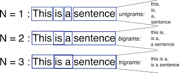

Subsetting by Label - can be useful to examine possible identifying words that are specific to each topic label in your df.

```
df_subset = df[df.label == topic]
```

Word Frequency - can be explored for your entire corpus or by subset to find important words and phrases that might help a ML model correctly classify an observation.

Word Clouds - are a good way to visualize word frequencies and word and phrase importance in your text data.

## Acquire News Articles

Here I pull in the text data I scraped in [this review](https://faithkane3.github.io/beautiful_soup) using BeautifulSoup.

```python
df = get_news_articles()
```

## Prepare News Articles

I'm going to use my cleaned, lemmatized text with basic stopwords removed to start; that is how my `prep_article_data` from [this review](https://faithkane3.github.io/nlp_review_notebook) delivers my text to me below. As I explore, I will probably be removing more stopwords and tokens that are just noise for my puposes as I come across them.

```python
df = prep_article_data(df)
```

```python
df.head()
```

|  | topic | title | author | content | clean_stemmed | clean_lemmatized |
| --- | --- | --- | --- | --- | --- | --- |
| 0 | business | US firm buys Serum Institute parent's Czech un... | Krishna Veera Vanamali | US biotech firm Novavax has announced it's buy... | us biotech firm novavax ha announc buy czech r... | u biotech firm novavax ha announced buying cze... |
| 1 | business | Twitter CEO donates $10M to project giving $1,... | Pragya Swastik | Twitter's billionaire CEO Jack Dorsey has dona... | twitter billionair ceo jack dorsey ha donat 10... | twitter billionaire ceo jack dorsey ha donated... |
| 2 | business | Google in talks to buy 5% stake in Vodafone Id... | Krishna Veera Vanamali | Google is exploring an investment in Vodafone ... | googl explor invest vodafon idea part us techn... | google exploring investment vodafone idea part... |
| 3 | business | Microsoft in talks to buy 2.5% stake in Jio fo... | Anushka Dixit | Microsoft is in talks with Mukesh Ambani-led R... | microsoft talk mukesh ambanil relianc industri... | microsoft talk mukesh ambaniled reliance indus... |
| 4 | business | 25-year-old Anant Ambani joins $65 billion Jio... | Krishna Veera Vanamali | Asia's richest person Mukesh Ambani's 25-year-... | asia richest person mukesh ambani 25yearold so... | asia richest person mukesh ambanis 25yearold s... |

### Extra Cleaning

As I explore my text data, I will find more things I want to remove. I know from exploring the text I scraped from inshort.com articles that there are a lot of numbers that are not useful to me for my purposes of sentiment analysis and creating a ML model that can predict the topic, or label, of an article. I'm going to remove numbers from my text here, and as I find more unnecessary tokens, I will return here to remove them as well.

```python
# Replace numbers in my text column with empty strings.

df['text'] = df.clean_lemmatized.replace(r'\d', '', regex=True)
df.head(2)
```

|  | topic | title | author | content | clean_stemmed | clean_lemmatized | text |
| --- | --- | --- | --- | --- | --- | --- | --- |
| 0 | business | US firm buys Serum Institute parent's Czech un... | Krishna Veera Vanamali | US biotech firm Novavax has announced it's buy... | us biotech firm novavax ha announc buy czech r... | u biotech firm novavax ha announced buying cze... | u biotech firm novavax ha announced buying cze... |
| 1 | business | Twitter CEO donates $10M to project giving $1,... | Pragya Swastik | Twitter's billionaire CEO Jack Dorsey has dona... | twitter billionair ceo jack dorsey ha donat 10... | twitter billionaire ceo jack dorsey ha donated... | twitter billionaire ceo jack dorsey ha donated... |

```python
# Remove extra stopwords identified through exploration using my `remove_stopwords()` function with extra_words

extra_words = ['', 'ha', 'wa', 'said', 'u']
df = remove_stopwords(df, 'text', extra_words=extra_words)
df.head()
```

|  | topic | title | author | content | clean_stemmed | clean_lemmatized | text | clean_text |
| --- | --- | --- | --- | --- | --- | --- | --- | --- |
| 0 | business | US firm buys Serum Institute parent's Czech un... | Krishna Veera Vanamali | US biotech firm Novavax has announced it's buy... | us biotech firm novavax ha announc buy czech r... | u biotech firm novavax ha announced buying cze... | u biotech firm novavax ha announced buying cze... | biotech firm novavax announced buying czech re... |
| 1 | business | Twitter CEO donates $10M to project giving $1,... | Pragya Swastik | Twitter's billionaire CEO Jack Dorsey has dona... | twitter billionair ceo jack dorsey ha donat 10... | twitter billionaire ceo jack dorsey ha donated... | twitter billionaire ceo jack dorsey ha donated... | twitter billionaire ceo jack dorsey donated mi... |
| 2 | business | Google in talks to buy 5% stake in Vodafone Id... | Krishna Veera Vanamali | Google is exploring an investment in Vodafone ... | googl explor invest vodafon idea part us techn... | google exploring investment vodafone idea part... | google exploring investment vodafone idea part... | google exploring investment vodafone idea part... |
| 3 | business | Microsoft in talks to buy 2.5% stake in Jio fo... | Anushka Dixit | Microsoft is in talks with Mukesh Ambani-led R... | microsoft talk mukesh ambanil relianc industri... | microsoft talk mukesh ambaniled reliance indus... | microsoft talk mukesh ambaniled reliance indus... | microsoft talk mukesh ambaniled reliance indus... |
| 4 | business | 25-year-old Anant Ambani joins $65 billion Jio... | Krishna Veera Vanamali | Asia's richest person Mukesh Ambani's 25-year-... | asia richest person mukesh ambani 25yearold so... | asia richest person mukesh ambanis 25yearold s... | asia richest person mukesh ambanis yearold son... | asia richest person mukesh ambanis yearold son... |

```python
# Select desired columns, topic and clean_text, for new df `df_lem` using clean, lemmatized text

df_lem = df[['topic', 'clean_text']]

# Rename columns to label and text

df_lem = df_lem.rename(columns={'topic': 'label', 'clean_text': 'text'})
df_lem.head(1)
```

|  | label | text |
| --- | --- | --- |
| 0 | business | biotech firm novavax announced buying czech re... |

```python
# Create a column called words that makes each text observation a list of tokens/words

df_lem['words'] = df_lem.text.str.split()
df_lem.head(2)
```

|  | label | text | words |
| --- | --- | --- | --- |
| 0 | business | biotech firm novavax announced buying czech re... | [biotech, firm, novavax, announced, buying, cz... |
| 1 | business | twitter billionaire ceo jack dorsey donated mi... | [twitter, billionaire, ceo, jack, dorsey, dona... |

## Explore Label Column

Our dataframe has 100 rows/observations and 3 columns; each observation is one article's text, the text as a list of tokens/words, and the label or topic of the article.`label` is one of four topics: business, entertainment, technology, and sports, which is our target variable. `text` is a string of tokens/words from each observation or article. `words` is the text broken into a list of tokens/words. I added the `words` column because I thought it could come in handy for feature engineering.

```python
print(f'Our df_lem dataframe has {df_lem.shape[0]} rows and {df_lem.shape[1]} columns')
```

```
Our df_lem dataframe has 100 rows and 3 columns
```

```python
# I only have four possible values for my label column. I'm going to make it a category dtype

df_lem.label.value_counts()
```

```
entertainment    25
business         25
sports           25
technology       25
Name: label, dtype: int64
```

```python
# Convert label column to category dtype

df_lem['label'] = df_lem.label.astype('category')
```

```python
# Our scraped data is very balanced!

# Concatenate our two Series' into a dataframe

labels = pd.concat([df_lem.label.value_counts(),
                    df_lem.label.value_counts(normalize=True)], axis=1)

# Rename columns

labels.columns = ['n', 'percent']
labels
```

|  | n | percent |
| --- | --- | --- |
| technology | 25 | 0.25 |
| sports | 25 | 0.25 |
| entertainment | 25 | 0.25 |
| business | 25 | 0.25 |

## Create Numeric Columns from Text

We can create some new numeric columns from our text. Here are two examples of numeric measures using aspects of our text data that might prove useful to classify our observations in our ML model.

```python
# Create a column that gives the length of the text/string for each observation

df_lem = df_lem.assign(text_length = df_lem.text.apply(len))
```

```python
# Create a column that gives the length of the text/string for each observation

df_lem = df_lem.assign(toke_count = df_lem.words.apply(len))
df_lem.head()
```

|  | label | text | words | text_length | toke_count |
| --- | --- | --- | --- | --- | --- |
| 0 | business | biotech firm novavax announced buying czech re... | [biotech, firm, novavax, announced, buying, cz... | 274 | 36 |
| 1 | business | twitter billionaire ceo jack dorsey donated mi... | [twitter, billionaire, ceo, jack, dorsey, dona... | 260 | 37 |
| 2 | business | google exploring investment vodafone idea part... | [google, exploring, investment, vodafone, idea... | 230 | 30 |
| 3 | business | microsoft talk mukesh ambaniled reliance indus... | [microsoft, talk, mukesh, ambaniled, reliance,... | 262 | 36 |
| 4 | business | asia richest person mukesh ambanis yearold son... | [asia, richest, person, mukesh, ambanis, yearo... | 245 | 34 |

## Identify Important Words in Text

### Create and Visualize N-grams

In creating a list of words to search my Corpus for the most common uni-, bi-, and trigrams, I see that I have single letters and truncated verbs that will not add meaning to my particular analysis. I will definitely go back to my extra cleaning section and remove the following stopwords: `['u', 'ha', 'wa', 'said']`

```python
# Create a list of words from the entire corpus

words = ' '.join(df_lem.text).split(' ')
words[:5]
```

```
['biotech', 'firm', 'novavax', 'announced', 'buying']
```

```python
# Create lists of uni-, bi-, and trigrams by calling the list function on our ngram iterator

unigrams = list(ngrams(words, 1))
bigrams = list(ngrams(words, 2))
trigrams = list(ngrams(words, 3))
```

```python
# Create a dictionary holding the uni-, bi-, and trigrams from our Corpus

grams_dict = {'unigrams': unigrams, 'bigrams': bigrams, 'trigrams': trigrams}
grams_dict.keys()
```

```
dict_keys(['unigrams', 'bigrams', 'trigrams'])
```

```python
# Check out our unigrams

grams_dict['unigrams'][:5]
```

```
[('biotech',), ('firm',), ('novavax',), ('announced',), ('buying',)]
```

```python
# Check out our bigrams

grams_dict['bigrams'][:3]
```

```
[('biotech', 'firm'), ('firm', 'novavax'), ('novavax', 'announced')]
```

```python
# Check out our trigrams

grams_dict['trigrams'][:2]
```

```
[('biotech', 'firm', 'novavax'), ('firm', 'novavax', 'announced')]
```

#### Create N-grams Function

I'll create a function to create a dictionary of uni-, bi-, and trigrams for a text column like I just did above.

```python
def grab_ngrams(df, col):
    '''
    This function takes in a df and a string name for a column, creates
    a list of words from entire corpus, and
    returns a dictionary holding all uni-, bi-, and trigrams.
    '''
    # create our corpus
    words = ' '.join(df[col]).split(' ')

    # create lists of uni-, bi-, and trigrams
    unigrams = list(ngrams(words, 1))
    bigrams = list(ngrams(words, 2))
    trigrams = list(ngrams(words, 3))

    # create a dictionary holding the uni-, bi-, and trigrams from our words
    grams_dict = {'unigrams': unigrams, 'bigrams': bigrams, 'trigrams': trigrams}

    return grams_dict
```

```python
ngrams_dict = grab_ngrams(df_lem, 'text')
ngrams_dict.keys()
```

```
dict_keys(['unigrams', 'bigrams', 'trigrams'])
```

#### Create N-Gram Viz Functions

I want to create two functions here.

- `ngrams_viz(ngrams_dict, topic)` will take in a dictionary of uni-, bi-, and trigrams and a string for topic and display viz for the top 20 most common n-grams by topic.
- `ngrams_compare()` will take in a df with a `label` column and a `text` column, an int: 1 for unigrams, 2 for bigrams, 3 for trigrams, a string for color customization, and an int to set the max value on the x-axis to equalize subplot axes and display subplots by topic with the top 20 common uni-, bi-, or trigrams.

```python
def ngrams_viz(ngram_dict, topic):
    '''
    This function takes in a dictionary of uni-, bi-, and trigrams
    and displays viz for the top 20 most common of each.
    '''
    # loop through the key in the dictionary
    for key in ngrams_dict:

        # convert value_counts to a Series and plot top 20
        (pd.Series(ngrams_dict[key])
         .value_counts()
         .head(20).plot.barh(color='thistle', width=.9)
        )

        plt.title('20 Most Common ' + topic + ' ' + key)

        # reorder y-axis of horizontal bar chart
        plt.gca().invert_yaxis()
        plt.show()
```

```python
# Visualize the top uni-, bi-, and trigrams for all of our words together

ngrams_viz(ngrams_dict, 'all')
```

[figure not shown]

### Explore Words by Topic Label

Here I will create a list of all of the tokens/words from our corpus of documents by topic. In our context, that means that we will join all of the text from each row of a text column into a long string of tokens/words, and those strings into lists of individual tokens/words. The difference here from the n-grams we explored above is that I will filter the df by topic creating subsets for each of our four topics.

#### Subset Business

```python
# Create subset of df_lem for business

biz_df = df_lem[df_lem.label == 'business']
biz_df.head(2)
```

|  | label | text | words | text_length | toke_count |
| --- | --- | --- | --- | --- | --- |
| 0 | business | biotech firm novavax announced buying czech re... | [biotech, firm, novavax, announced, buying, cz... | 274 | 36 |
| 1 | business | twitter billionaire ceo jack dorsey donated mi... | [twitter, billionaire, ceo, jack, dorsey, dona... | 260 | 37 |

```python
# Create dictionary holding uni-, bi-, and trigrams from biz_df using our `grab_ngrams` function

biz_grams = grab_ngrams(biz_df, 'text')
biz_grams.keys()
```

```
dict_keys(['unigrams', 'bigrams', 'trigrams'])
```

#### Subset Entertainment

```python
# Create subset of df_lem for entertainment

entertainment_df = df_lem[df_lem.label == 'entertainment']
entertainment_df.head(2)
```

|  | label | text | words | text_length | toke_count |
| --- | --- | --- | --- | --- | --- |
| 75 | entertainment | ip officer ravi mohan saini crore kbc junior y... | [ip, officer, ravi, mohan, saini, crore, kbc, ... | 219 | 33 |
| 76 | entertainment | actress maanvi gagroo criticised clothing stor... | [actress, maanvi, gagroo, criticised, clothing... | 225 | 32 |

```python
# create dictionary of uni-, bi-, and trigrams from entertainment_df using our `grab_ngrams` function

ent_grams = grab_ngrams(entertainment_df, 'text')
ent_grams.keys()
```

```
dict_keys(['unigrams', 'bigrams', 'trigrams'])
```

#### Subset Sports

```python
# create subset of df_lem for sports

sports_df = df_lem[df_lem.label == 'sports']
sports_df.head(2)
```

|  | label | text | words | text_length | toke_count |
| --- | --- | --- | --- | --- | --- |
| 25 | sports | exindia captain rahul dravid idea creating bio... | [exindia, captain, rahul, dravid, idea, creati... | 208 | 29 |
| 26 | sports | icc cricket committee chairman anil kumble rea... | [icc, cricket, committee, chairman, anil, kumb... | 245 | 35 |

```python
# create dictionary of uni-, bi-, and trigrams from sports_df using our `grab_ngrams` function

sports_grams = grab_ngrams(sports_df, 'text')
sports_grams.keys()
```

```
dict_keys(['unigrams', 'bigrams', 'trigrams'])
```

#### Subset Tech

```python
# create subset of df_lem for technology

tech_df = df_lem[df_lem.label == 'technology']
tech_df.head(2)
```

|  | label | text | words | text_length | toke_count |
| --- | --- | --- | --- | --- | --- |
| 50 | technology | day twitter factchecked president donald trump... | [day, twitter, factchecked, president, donald,... | 270 | 34 |
| 51 | technology | twitter ceo jack dorsey defended company decis... | [twitter, ceo, jack, dorsey, defended, company... | 267 | 36 |

```python
# create dictionary of uni-, bi-, and trigrams from tech_df using our `grab_ngrams` function

tech_grams = grab_ngrams(tech_df, 'text')
tech_grams.keys()
```

```
dict_keys(['unigrams', 'bigrams', 'trigrams'])
```

```python
def ngrams_compare(df, num, color, xlim):
    '''
    This function takes in a df with a 'label' column and a 'text' column,
    an int: 1 for unigrams, 2 for bigrams, 3 for trigrams, a string for color customization,
    and an int to set the max value on the x-axis to equalize subplot axes
    and displays horizontal bar chart subplots by topic with the top 20 common uni-, bi-, or trigrams.
    '''
    # create topics list to loop through
    topics = df.label.unique()

    # create figure for subplots
    plt.figure(figsize=(16, 12))

    # loop through topics
    for i, topic in list(enumerate(topics, start=1)):

        # assign subtopic df to temp_df
        temp_df = df[df.label == topic]

        # create a list of words from entire corpus
        words = ' '.join(temp_df['text']).split(' ')

        # create lists of uni-, bi-, and trigrams
        n_grams = list(ngrams(words, num))

        subplot(2,2,i)

        (pd.Series(n_grams)
                .value_counts()
                .head(20)
                .plot.barh(color=color, width=.9, fontsize=15)
        )

        # print customized title
        plt.title('20 Most Common ' + topic + ' ' + str(num) + '-grams', fontsize=20)

        # set x-axis of horizontal bar chart
        plt.xlim(0, xlim)

        # reorder y-axis of horizontal bar chart
        plt.gca().invert_yaxis()

    # display settings
    plt.tight_layout()
    plt.show()
```

```python
ngrams_compare(df_lem, 1, 'thistle', 16)
```

[figure not shown]

```python
ngrams_compare(df_lem, 2, 'dodgerblue', 7)
```

[figure not shown]

```python
ngrams_compare(df_lem, 3, 'darkorange', 6)
```

[figure not shown]

### Word Frequency by Topic Label

Now we can look at word importance or word frequency for each individual subset.

```python
# Create a list of all words from corpus from subset biz_df

business_words = ' '.join(biz_df.text).split(' ')
business_words[:5]
```

```
['biotech', 'firm', 'novavax', 'announced', 'buying']
```

```python
# Create a Series of word frequency from our list of business words

business_freq = pd.Series(business_words).value_counts()
business_freq.head()
```

```
billion       14
company       13
crore         10
investment     9
india          9
dtype: int64
```

```python
business_freq.tail()
```

```
largest    1
looking    1
fund       1
founded    1
cyrus      1
dtype: int64
```

```python
# Create a list of all words from corpus from subset entertainment_df

entertainment_words = ' '.join(entertainment_df.text).split(' ')

# Create a Series of word frequency from our list of entertainment words

entertainment_freq = pd.Series(entertainment_words).value_counts()
entertainment_freq.head()
```

```
film       15
added      12
actor      10
role        9
actress     7
dtype: int64
```

```python
entertainment_freq.tail()
```

```
cine     1
train    1
child    1
v        1
urged    1
dtype: int64
```

```python
# Create a list of all words from corpus from subset entertainment_df

sports_words = ' '.join(sports_df.text).split(' ')

# Create a Series of word frequency from our list of sports words

sports_freq = pd.Series(sports_words).value_counts()
sports_freq.head()
```

```
captain    11
added      11
test       10
cricket    10
batsman     8
dtype: int64
```

```python
sports_freq.tail()
```

```
saleem      1
sort        1
starting    1
major       1
negative    1
dtype: int64
```

```python
# Create a list of all words from corpus from subset tech_df

tech_words = ' '.join(tech_df.text).split(' ')

# Create a Series of word frequency from our list of tech words

technology_freq = pd.Series(tech_words).value_counts()
technology_freq.head()
```

```
user        13
facebook    11
trump       11
platform    10
google      10
dtype: int64
```

```python
technology_freq.tail()
```

```
ai           1
consent      1
divisive     1
implement    1
exploring    1
dtype: int64
```

```python
# Create a list of all words from corpus

all_words = ' '.join(df_lem.text).split(' ')

# Create a Series of word frequency from our list of all words

all_freq = pd.Series(all_words).value_counts()
all_freq.head()
```

```
added      33
billion    23
india      22
company    19
time       18
dtype: int64
```

```python
all_freq.tail()
```

```
debut     1
smooth    1
zhao      1
k         1
okay      1
dtype: int64
```

### Word Frequency df by Topic Label

I can concatenate all of the word frequency Series' we created above into a single df, `word_counts` for further investigation. By sorting the values by different columns or topics, I can begin to identify words that are distinct to one topic or another or are more common to individual topics.

```python
# Concatenate all of the word frequency Series' from above into a df called `word_counts`

word_counts = (pd.concat([business_freq, entertainment_freq, sports_freq, technology_freq, all_freq], axis=1, sort=True)
              .set_axis(['all', 'business', 'entertainment', 'sports', 'technology'], axis=1, inplace=False)
              .fillna(0)
              .apply(lambda s: s.astype(int)))

word_counts.head()
```

[output not shown]

```python
# Compare most common words in sports articles to other types of articles

word_counts.sort_values(by='sports', ascending=False).head(20)
```

[output not shown]

### Search for Topic-specific Words

```python
# What words are not in business articles but ARE in other categories of articles?

word_counts[word_counts.business == 0].head(10)
```

[output not shown]

### Word Clouds!

**Word Clouds are a great way to visualize word importance or word frequency in your text data.** The default word cloud background is black, which can look pretty cool, but there are many, many ways to customize not only the look but the functionality of your word clouds.

Here, we'll look at word frequency for the subsets of business articles and technology articles using different customizations. We will also look at a word cloud that visualizes the frequency of the top 20 most common bigrams for the business subset and a word cloud using a mask to shape the cloud.

**These examples should give you a great start with customizing word clouds to visualize your text data.**

**Step 1: Import Libraries.**

```
python -m pip install --upgrade wordcloud
```

```
from wordcloud import WordCloud
```

```
import matplotlib.pyplot as plt
```

```
# import for making mask
from PIL import Image
```

**Step 2: Create a list of words for your cloud, in this case from your text column.**

```
words = ' '.join(df['text']).split(' ')
```

**Step 3: Create the WordCloud Object.**

```
wordcloud = WordCloud().generate(words)
```

**Step 4: Display the Image.**

```
plt.imshow(wordcloud)
```

```
plt.axis('off')
```

```
plt.show()
```

#### Standard Word Cloud

```python
plt.rcParams['figure.figsize'] = (14, 7)

technology_cloud = WordCloud().generate(' '.join(tech_words))

plt.imshow(technology_cloud)
plt.axis('off')
plt.title('Technology Article Words', fontsize=15)
plt.show()
```

[figure not shown]

#### Customized Word Cloud

```python
plt.rcParams['figure.figsize'] = (14, 7)

business_cloud = WordCloud(background_color='white', colormap=plt.cm.Dark2,
                           height=1000, width=1400).generate(' '.join(business_words))

plt.imshow(business_cloud)
plt.axis('off')
plt.title('Business Article Words', fontsize=15)
plt.show()
```

[figure not shown]

#### Bigram Word Cloud

Creating a word cloud using bigrams can be a bit more involved. We'll go through the process step-by-step below. You can use this process for trigrams, too, of course.

```python
# Create a Series of frequencies for our top 20 business bigrams

top_20_biz_bigrams = pd.Series(biz_grams['bigrams']).value_counts().head(20)
top_20_biz_bigrams.head(2)
```

```
(jio, platform)    4
(lakh, crore)      4
dtype: int64
```

```python
# Create a dictionary in which the keys are the bigrams tuples and the values the frequencies of bigrams

biz_bigram_dict = top_20_biz_bigrams.to_dict().items()
biz_bigram_dict
```

[output not shown]

```python
# Use a dictionary comprehension to return a dictionary with bigram as key and frequency as value

data = {key[0] + ' ' + key[1]: val for key, val in biz_bigram_dict}
data
```

```
{'jio platform': 4,
 'lakh crore': 4,
 'reliance industry': 3,
 'virgin orbit': 3,
 'raised billion': 3,
 'coronavirus pandemic': 3,
 'billion month': 3,
 'nonconvertible debenture': 2,
 'reliance group': 2,
 'cease subscription': 2,
 'jio raised': 2,
 'saving bond': 2,
 'finance minister': 2,
 'firstever bond': 2,
 'vodafone idea': 2,
 'baba ramdevled': 2,
 'financial package': 2,
 'donated million': 2,
 'government announced': 2,
 'patanjali ayurveds': 2}
```

```python
# Create and display bigram word cloud. This time we will use the `generate_from_frequencies` method

business_bigram_cloud = WordCloud(background_color='white', colormap=plt.cm.tab10,
                           height=1000, width=1400).generate_from_frequencies(data)

plt.imshow(business_bigram_cloud)
plt.axis('off')
plt.title('Business Article Top 20 Bigrams', fontsize=15)
plt.show()
```

[figure not shown]

#### Shaped Word Cloud

I found [this article](https://www.datacamp.com/community/tutorials/wordcloud-python) really helpful in learning how to create masks to shape my word clouds.

```python
# You need this import

from PIL import Image
```

```python
# Create and check mask using saved png file in my directory

b_mask = np.array(Image.open('b.png'))
b_mask
```

```
array([[ 1,  1,  1, ...,  0,  0,  0],
       [ 1,  1,  1, ...,  0,  0,  0],
       [ 1,  1,  1, ...,  0,  0,  0],
       ...,
       [ 1,  1,  1, ...,  0,  0,  0],
       [16, 16, 16, ...,  0,  0,  0],
       [39, 39, 32, ...,  0,  0,  0]], dtype=uint8)
```

```python
# Function to transform the white part of the mask to 255 (integer), pure white

def transform_format(val):
    if val == 0:
        return 255
    if val == 1:
        return 255
    else:
        return val
```

```python
# Transform mask into a new one that will work with the function:

transformed_b_mask = np.ndarray((b_mask.shape[0],b_mask.shape[1]), np.int32)

for i in range(len(b_mask)):
    transformed_b_mask[i] = list(map(transform_format, b_mask[i]))
```

```python
# Create cloud

biz_shape_cloud = WordCloud(background_color='white', colormap=plt.cm.Dark2,
                                   mask=transformed_b_mask, contour_width=3, contour_color='black',
                                  height=1000, width=1400).generate(' '.join(business_words))

# Save biz_shape_cloud.png to your current directory if you want

#biz_shape_cloud.to_file("biz_shape_cloud.png")

# Display cloud

plt.figure(figsize=[20,10])
plt.imshow(biz_shape_cloud)
plt.axis('off')
plt.show()
```

[figure not shown]